# GEO 812 – Solution 1: Data exploration

## Finding the most recent entries

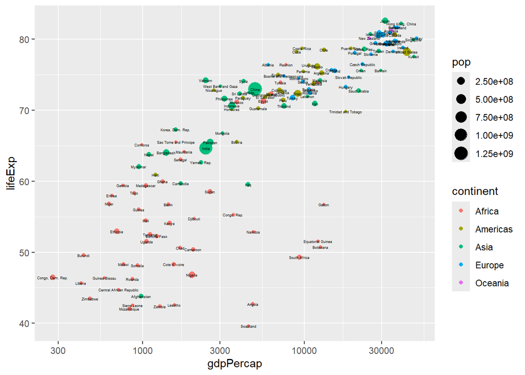

```r
gapminder_recent <- gapminder |> filter(year == max(year))
gapminder_recent |>
  ggplot(aes(x=gdpPercap, y=lifeExp)) +
    geom_point(aes(color=continent, size=pop)) +
    geom_label(aes(label=country), size=1.2, alpha=0, label.size = 0) +
    scale_x_log10()
```

## Highest life-expectancy

To find the countries with the highest life expectancy, we can sort the data frame using `arrange` and take the last entries using `tail`:

```r
gapminder_recent |>
  dplyr::select(country, lifeExp) |>
  arrange(lifeExp) |>
  tail(5)
```

```
# A tibble: 5 × 2
  country          lifeExp
  <fct>              <dbl>
1 Australia           81.2
2 Switzerland         81.7
3 Iceland             81.8
4 Hong Kong, China    82.2
5 Japan               82.6
```

Of course, we could also do the same to find the countries with the highest GDP per capita.

```r
gapminder_recent |>
  dplyr::select(country, gdpPercap, pop) |>
  arrange(gdpPercap) |>
  tail()
```

```
# A tibble: 6 × 3
  country          gdpPercap       pop
  <fct>                <dbl>     <int>
1 Hong Kong, China    39725.   6980412
2 Ireland             40676.   4109086
3 United States       42952. 301139947
4 Singapore           47143.   4553009
5 Kuwait              47307.   2505559
6 Norway              49357.   4627926
```

## Continent GDP (absolute and per capita)

Before aggregating GDP by continent, we need to calculate the absolute GDP for each country by multiplying GDP per capita by the population size.

```r
gapminder_recent <- gapminder_recent |> mutate(gdp = pop * gdpPercap)
head(gapminder_recent)
```

```
# A tibble: 6 × 7
  country     continent  year lifeExp      pop gdpPercap           gdp
  <fct>       <fct>     <int>   <dbl>    <int>     <dbl>         <dbl>
1 Afghanistan Asia       2007    43.8 31889923      975.  31079291949.
2 Albania     Europe     2007    76.4  3600523     5937.  21376411360.
3 Algeria     Africa     2007    72.3 33333216     6223. 207444851958.
4 Angola      Africa     2007    42.7 12420476     4797.  59583895818.
5 Argentina   Americas   2007    75.3 40301927    12779. 515033625357.
6 Australia   Oceania    2007    81.2 20434176    34435. 703658358894.
```

Now we can use `group_by` and `summarise` to obtain the total GDP and population for each continent.

```r
gapminder_continents <- gapminder_recent |>
  group_by(continent) |>
  summarise(gdp = sum(gdp), pop=sum(pop)) |>
  arrange(gdp)

gapminder_continents
```

```
# A tibble: 5 × 3
  continent     gdp        pop
  <fct>       <dbl>      <dbl>
1 Oceania   8.07e11   24549947
2 Africa    2.38e12  929539692
3 Europe    1.48e13  586098529
4 Americas  1.94e13  898871184
5 Asia      2.07e13 3811953827
```

As we can see, Asia identifies the continent with the highest GDP.

For GDP per capita, you might be tempted to simply take the mean of the country GDP values.

```r
gapminder_recent |>
  group_by(continent) |>
  summarise(gdpPercap = mean(gdpPercap)) |>
  arrange(gdpPercap)
```

```
# A tibble: 5 × 2
  continent gdpPercap
  <fct>         <dbl>
1 Africa        3089.
2 Americas     11003.
3 Asia         12473.
4 Europe       25054.
5 Oceania      29810.
```

However, this approach would ignore differences in population size (e.g., India and Kuwait would be weighted the same). Instead, we can recalculate `gdpPercap` from the aggregated `gdp` and `pop`:

```r
gapminder_continents <- gapminder_continents |>
  mutate(gdpPercap=gdp / pop) |>
  arrange(gdpPercap)
gapminder_continents
```

```
# A tibble: 5 × 4
  continent     gdp        pop gdpPercap
  <fct>       <dbl>      <dbl>     <dbl>
1 Africa    2.38e12  929539692     2561.
2 Asia      2.07e13 3811953827     5432.
3 Americas  1.94e13  898871184    21603.
4 Europe    1.48e13  586098529    25244.
5 Oceania   8.07e11   24549947    32885.
```

Alternatively, we can use the `weighted.mean` function to directly compute the weighted mean of GDP per capita for each country:

```r
gapminder_recent |>
  group_by(continent) |>
  summarise(gdpPercap = weighted.mean(gdpPercap, pop)) |>
  arrange(gdpPercap)
```

```
# A tibble: 5 × 2
  continent gdpPercap
  <fct>         <dbl>
1 Africa        2561.
2 Asia          5432.
3 Americas     21603.
4 Europe       25244.
5 Oceania      32885.
```

As you can see, the difference from the naive mean is quite notable. Still, with either method, we would find that Oceania has the highest GDP per capita.